# glmhmm metacognition

```r
library(reticulate)
use_condaenv("glmhmm")

source_python("python/glm_hmm.py")
```

```python
import numpy as np
import numpy.random as npr
import matplotlib.pyplot as plt
import ssm
#from ssm.util import find_permutation
```

```r
library(cowplot)
```

| Download of data (Buno) |
| --- |

- stimulus refers to which group of dots (right or left) has more of them (check; the quantity of trials with more dots either on the left or right group varies from subject to subject).
- dot_diff is the difference of dots between stimuli (subject where asked which stimulus had more dots).
- confidence is the confidence scale meassured with a 11-point probabilistic rating scale (1=certainly wrong, 3=probably wrong, 5=maybe wrong, 7=maybe correct, 9=probably correct, 11=certainly correct)

```r
data_trials <- read_csv("data/data_Rouault_2018_Expt1.csv", show_col_types = FALSE)
data_trials <- rename(data_trials, subject = Subj_idx, stimulus = Stimulus, response = Response, confidence = Confidence, RT = RT_dec, dot_diff = DotDiff, correct = Accuracy)

data_trials <- data_trials |>
  group_by(subject) |>
  mutate(trial = row_number()) |>
  ungroup() |>
  mutate(stimulus = if_else(stimulus == 0, -1, 1),
         dot_diff = stimulus * dot_diff,
         prev_resp = lag(response),
         fing_err = if_else(confidence == 1, 1, 0)) |>
  drop_na()

data_trials
```

| subject | stimulus | response | confidence | RT | dot_diff | correct | trial | prev_resp | fing_err |
| --- | --- | --- | --- | --- | --- | --- | --- | --- | --- |
| 1 | 1 | 0 | 9 | 0.626 | 15 | 0 | 2 | 0 | 0 |
| 1 | 1 | 1 | 5 | 1.253 | 13 | 1 | 3 | 0 | 0 |
| 1 | 1 | 1 | 8 | 0.634 | 2 | 1 | 4 | 1 | 0 |
| 1 | 1 | 1 | 7 | 0.731 | 49 | 1 | 5 | 1 | 0 |
| 1 | 1 | 1 | 8 | 0.567 | 52 | 1 | 6 | 1 | 0 |
| 1 | -1 | 0 | 7 | 2.487 | -33 | 1 | 7 | 1 | 0 |
| 1 | -1 | 1 | 7 | 0.744 | -4 | 0 | 8 | 0 | 0 |
| 1 | -1 | 1 | 8 | 0.504 | -58 | 0 | 9 | 1 | 0 |
| 1 | 1 | 1 | 8 | 0.557 | 21 | 1 | 10 | 1 | 0 |
| 1 | -1 | 0 | 7 | 0.856 | -6 | 1 | 11 | 1 | 0 |

[output cut: 990 more lines]

| General analysis |
| --- |

Proportions of left (-1) and right (1) stimuli

```r
data_trials |>
  group_by(subject) |>
  count(stimulus) |>
  group_by(subject) |>
  mutate(prop = n / sum(n)) |>
  select(-n) |>
  pivot_wider(names_from = stimulus, values_from = prop)
```

| subject | -1 | 1 |
| --- | --- | --- |
| 1 | 0.5502392 | 0.4497608 |
| 2 | 0.5476190 | 0.4523810 |
| 3 | 0.4761905 | 0.5238095 |
| 4 | 0.4523810 | 0.5476190 |
| 5 | 0.5238095 | 0.4761905 |
| 6 | 0.4523810 | 0.5476190 |
| 7 | 0.4761905 | 0.5238095 |
| 8 | 0.5238095 | 0.4761905 |
| 9 | 0.5000000 | 0.5000000 |
| 10 | 0.5238095 | 0.4761905 |

[output cut: 488 more lines]

## ———————————————————————

## 2S GENERAL

MEJOR LLAMAR A s01_trials ALGO QUE PONGA DESIGN MATRIX QUE ES LO QUE ES

[output not shown]

[output cut: 990 more lines]

```r
s02_trials <- data_trials %>%
  filter(subject == 2) %>%
  mutate(session = 1,
         intercept = 1,
         dot_diff = dot_diff) %>%
  ungroup() %>%
  select(session, response, intercept, dot_diff)

s02_trials
```

| session | response | intercept | dot_diff |
| --- | --- | --- | --- |
| 1 | 1 | 1 | 51 |
| 1 | 1 | 1 | -25 |
| 1 | 1 | 1 | 30 |
| 1 | 0 | 1 | -10 |
| 1 | 1 | 1 | 31 |
| 1 | 1 | 1 | -15 |
| 1 | 0 | 1 | -1 |
| 1 | 0 | 1 | -16 |
| 1 | 0 | 1 | -54 |
| 1 | 1 | 1 | -4 |

[output cut: 200 more lines]

[output not shown]

```r
glm_hmm2_s01_seeds <- s01_trials %>%
  glm_hmm_r(.num_states = 2, .seeds = 1:40, .all_seeds = TRUE)

glm_hmm2_s01_seeds
```

| seed | log_lik | n_par | fit |
| --- | --- | --- | --- |
| 1 | -105.5346 | 6 |  |
| 2 | -105.5347 | 6 |  |
| 3 | -105.5346 | 6 |  |
| 4 | -105.5346 | 6 |  |
| 5 | -105.5346 | 6 |  |
| 6 | -105.5346 | 6 |  |
| 7 | -105.5346 | 6 |  |
| 8 | -105.5347 | 6 |  |
| 9 | -105.5346 | 6 |  |
| 10 | -105.5347 | 6 |  |

[output cut: 30 more lines]

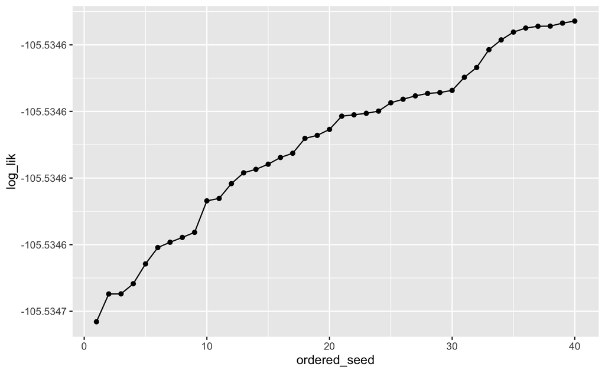

```r
glm_hmm2_s01_seeds %>%
  arrange(log_lik) %>%
  mutate(ordered_seed = row_number()) %>%
  ggplot(aes(ordered_seed, log_lik)) +
  geom_line() +
  geom_point()
```

```r
glm_hmm2_s01 <- glm_hmm2_s01_seeds |>
   filter(log_lik == max(log_lik)) |>
   pluck("fit") %>%
   pluck(1)

glm_hmm2_s01
```

| session | response | intercept | dot_diff |
| --- | --- | --- | --- |
| 1 | 0 | 1 | 15 |
| 1 | 1 | 1 | 13 |
| 1 | 1 | 1 | 2 |
| 1 | 1 | 1 | 49 |
| 1 | 1 | 1 | 52 |
| 1 | 0 | 1 | -33 |
| 1 | 1 | 1 | -4 |
| 1 | 1 | 1 | -58 |
| 1 | 1 | 1 | 21 |
| 1 | 0 | 1 | -6 |

[output cut: 199 more lines]

```
$log_prob
[1] -136.8414

$log_prior
[1] -31.30678

$log_lik
[1] -105.5346

$n_par
[1] 6

$recovered_weights
```

| state | coef | value |
| --- | --- | --- |
| S1 | V1 | 1.22262202 |
| S1 | V2 | 0.02198381 |
| S2 | V1 | 0.76216724 |
| S2 | V2 | 0.06864497 |

```
$transitions_tengo_que_reordenar_segun_estados_ordenados
             [,1]        [,2]
[1,] -0.008147865 -4.81407055
[2,] -3.395870222 -0.03408575

$posterior_probs
```

| session | trial | state | p |
| --- | --- | --- | --- |
| 1 | 1 | S1 | 1.000000e+00 |
| 1 | 1 | S2 | 3.997272e-09 |
| 1 | 2 | S1 | 9.975170e-01 |
| 1 | 2 | S2 | 2.483002e-03 |
| 1 | 3 | S1 | 9.955959e-01 |
| 1 | 3 | S2 | 4.404079e-03 |
| 1 | 4 | S1 | 9.938955e-01 |
| 1 | 4 | S2 | 6.104536e-03 |
| 1 | 5 | S1 | 9.929136e-01 |
| 1 | 5 | S2 | 7.086436e-03 |

[output cut: 408 more lines]

```
NA
```

```r
psycho_2_s01 <- glm_hmm2_s01$recovered_weights |>
  group_by(state) |>
  reframe(create_psychometric(dot_diff, value))
```

```r
posterior_wins2_s01 <- glm_hmm2_s01$posterior_probs |>
    group_by(trial) %>%
    filter(p == max(p)) %>%
    select(-p)

posterior_wins2_s01
```

```r
averages_states2_s01 <- glm_hmm2_s01$model_matrix_with_session %>%
    mutate(trial = row_number()) %>%
    left_join(posterior_wins2_s01, by = c("session", "trial")) %>%
    mutate(dot_diff_bin = cut_interval(dot_diff, 10)) |>
    group_by(dot_diff_bin, state) %>%
    summarise(dot_diff = mean(dot_diff), prob = mean(response), n = n(), .groups = "keep")
```

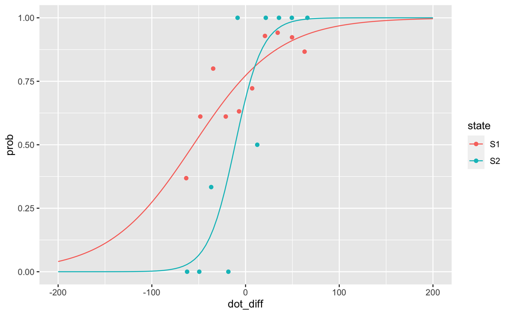

```r
ggplot() +
  geom_point(data = averages_states2_S01,
             aes(dot_diff, prob, color = state)) +
  geom_line(data = psycho_2_s01,
            aes(x = dot_diff, y = prop, color = state))
```

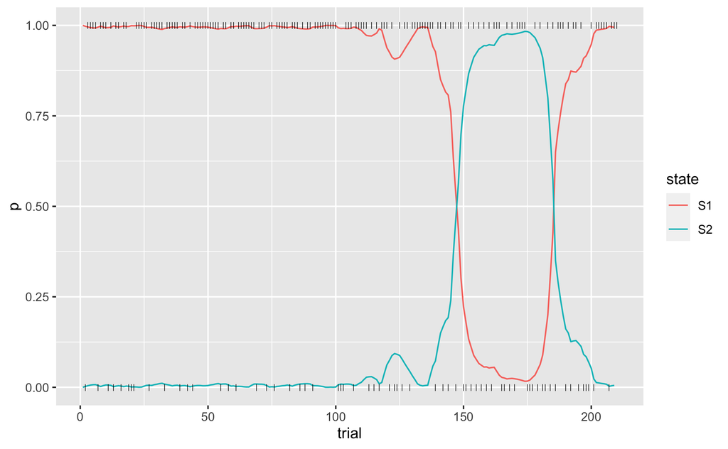

```r
s01_2_trials_plot <- ggplot() +
  geom_line(data = glm_hmm2_s01$posterior_probs,
            aes(x = trial, y = p, color = state)) +
  geom_point(data = filter(data_trials, subject == 1), aes(x = trial, y = response), shape = "|")

s01_2_trials_plot
```

```r
posterior_wins2_s01 |>
  ungroup() |>
  count(state)
```

| state | n |
| --- | --- |
| S1 | 171 |
| S2 | 38 |

MEJOR HACER FUNCIONES PARA EL PLOT

```r
plotting_psycho_one_participant <- function(.fit) {

  posterior_wins <- .fit$posterior_probs |>
    group_by(trial) %>%
    filter(p == max(p)) %>%
    select(-p)

  averages <- .fit$model_matrix_with_session %>%
    mutate(trial = row_number()) %>%
    left_join(posterior_wins, by = c("session", "trial")) %>%
    mutate(dot_diff_bin = cut_interval(dot_diff, 10)) |>
    group_by(dot_diff_bin, state) %>%
    summarise(dot_diff = mean(dot_diff), prob = mean(response), n = n(), .groups = "keep")

  psycho <- glm_hmm2_s01$recovered_weights |>
  group_by(state) |>
  reframe(create_psychometric(dot_diff, value))

  ggplot() +
  geom_point(data = averages,
             aes(dot_diff, prob, color = state)) +
  geom_line(data = psycho,
            aes(x = dot_diff, y = prop, color = state))
}
```

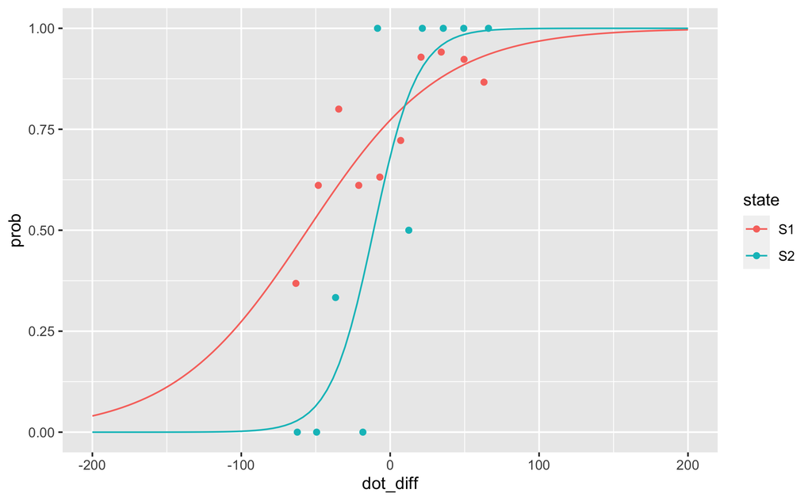

```r
plotting_psycho_one_participant(glm_hmm2_s01)
```

```r
plotting_trials_one_participant <- function(.fit) {

  ggplot() +
  geom_line(data = .fit$posterior_probs,
            aes(x = trial, y = p, color = state))
}
```

Esto lo tienes que arreglar para que tambien plotee las respuestas como antes

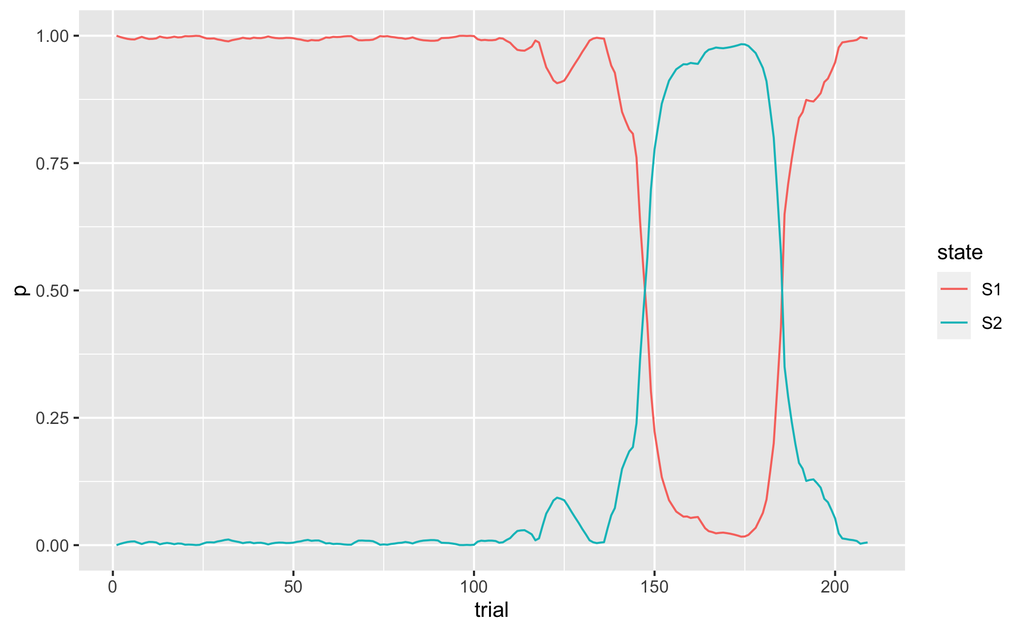

```r
plotting_trials_one_participant(glm_hmm2_s01)
```

Necistas instalar cowplot:

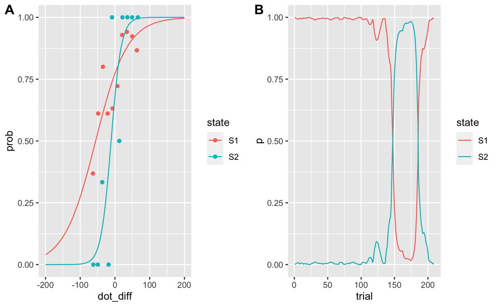

```r
plot_grid(plotting_psycho_one_participant(glm_hmm2_s01),
          plotting_trials_one_participant(glm_hmm2_s01),
          rel_widths = c(.5, .5),
          labels = "AUTO"
)
```

```r
plotting_one_participant <- function(.fit) {
  plot_grid(plotting_psycho_one_participant(.fit),
          plotting_trials_one_participant(.fit),
          rel_widths = c(.5, .5),
          labels = "AUTO")
}
```

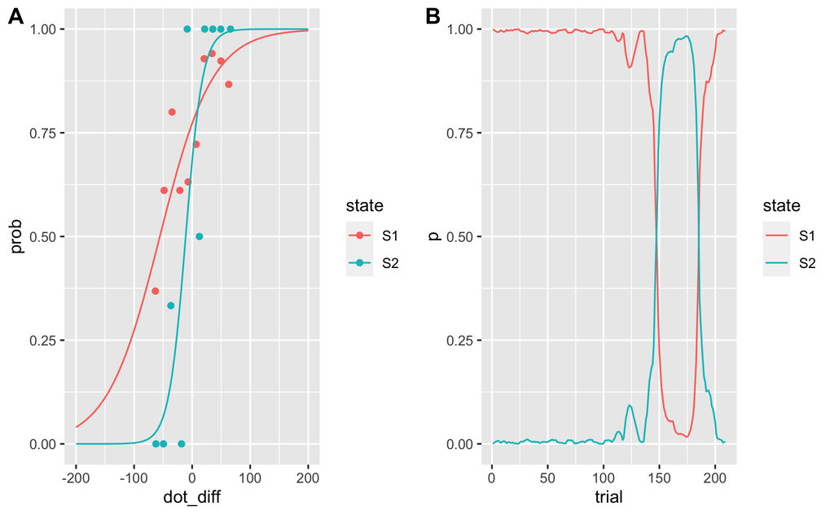

```r
plotting_one_participant(glm_hmm2_s01)
```

| MUCHOS PARTICIPANTES |
| --- |

Solo lo hago con 10 participantes porque tarda mucho. Después habra que hacerlo con todos

```r
design_matrix <- data_trials %>%
  mutate(session = 1,
         intercept = 1,
         dot_diff = dot_diff) %>%
  ungroup() %>%
  select(subject, session, response, intercept, dot_diff) |>
  filter(subject <= 10) # solo 10 participantes

design_matrix
```

| subject | session | response | intercept | dot_diff |
| --- | --- | --- | --- | --- |
| 1 | 1 | 0 | 1 | 15 |
| 1 | 1 | 1 | 1 | 13 |
| 1 | 1 | 1 | 1 | 2 |
| 1 | 1 | 1 | 1 | 49 |
| 1 | 1 | 1 | 1 | 52 |
| 1 | 1 | 0 | 1 | -33 |
| 1 | 1 | 1 | 1 | -4 |
| 1 | 1 | 1 | 1 | -58 |
| 1 | 1 | 1 | 1 | 21 |
| 1 | 1 | 0 | 1 | -6 |

[output cut: 990 more lines]

Esto tarda mucho porque hace muchos ajustes:

```r
glm_hmm_all_seeds_2 <- design_matrix |>
  group_by(subject) |>
  nest() %>%
  rowwise() %>%
  mutate(fit = list(glm_hmm_r(data,
                              .num_states = 2, .seeds = 1:20,
                              .all_seeds = TRUE)))
```

Como tarda tanto habra que usar save para guardar los resultados

y load cuando quieras cargarlos:

```r
#load("RData/glm_hmm_all_seeds_2.RData")
```

```r
glm_hmm_extract_best <- function(.fits) {
  .fits %>%
    filter(log_lik == max(log_lik)) %>%
    pluck("fit") %>%
    pluck(1)
}
```

[output not shown]

Los parametros estimados para cada sujeto

```r
glm_hmm_2 %>%
      select(-data) %>%
      unnest_wider(fit) %>%
      select(subject, recovered_weights) %>%
      unnest(recovered_weights)
```

| subject | state | coef | value |
| --- | --- | --- | --- |
| 1 | S1 | V1 | 1.222625569 |
| 1 | S1 | V2 | 0.021983828 |
| 1 | S2 | V1 | 0.762122625 |
| 1 | S2 | V2 | 0.068642821 |
| 2 | S1 | V1 | 0.776531656 |
| 2 | S1 | V2 | 0.042501410 |
| 2 | S2 | V1 | 0.994784277 |
| 2 | S2 | V2 | 0.043921662 |
| 3 | S1 | V1 | -0.327137629 |
| 3 | S1 | V2 | 0.055047252 |

[output cut: 30 more lines]

| subject | log_lik | n_par | n | model |
| --- | --- | --- | --- | --- |
| 1 | -105.53463 | 6 | 209 | int-slo 2 |
| 2 | -94.19537 | 6 | 210 | int-slo 2 |
| 3 | -85.35144 | 6 | 210 | int-slo 2 |
| 4 | -101.45020 | 6 | 210 | int-slo 2 |
| 5 | -77.91941 | 6 | 210 | int-slo 2 |
| 6 | -67.78228 | 6 | 210 | int-slo 2 |
| 7 | -119.99256 | 6 | 210 | int-slo 2 |
| 8 | -97.51248 | 6 | 210 | int-slo 2 |
| 9 | -77.26874 | 6 | 210 | int-slo 2 |
| 10 | -98.46876 | 6 | 210 | int-slo 2 |

plotting

[output not shown]

Habria que añadir el nombre del participante. Una solucion es que la función plotting_one_participant le pases (fit, subject) y

que uses un geom_text en el plot para que te ponga en algun sitio del grafico el número de participante. Puedes intentarlo y si no lo hablamos.

HASTA AQUI

| 10 rand 2S |
| --- |

```r
rand_10_sub <- unique(data_trials$subject)
rand_10_sub <- rand_10_sub |>
  sample(10)

rand_10_sub_trials <- data_trials |>
  filter(subject %in% rand_10_sub) |>
  mutate(session = 1,
         intercept = 1,
         dot_diff = dot_diff) |>
  ungroup() |>
  select(session, response, intercept, dot_diff)
```

```r
glm_hmm2_10 <- rand_10_sub_trials %>%
  glm_hmm_r(.num_states = 2)
glm_hmm2_10
```

```r
glm_hmm2_10$recovered_weights
```

```r
psycho_2_10 <- glm_hmm2_10$recovered_weights |>
  group_by(state) |>
  reframe(create_psychometric(dot_diff, value))
```

```r
psycho_2_10 |>
  ggplot(aes(x = dot_diff, y = prop, color = state)) +
  geom_line()
```

Predominancia:

```r
posterior_wins2_10 <- glm_hmm2_10$posterior_probs |>
    group_by(trial) %>%
    filter(p == max(p)) %>%
    select(-p)

posterior_wins2_10
```

```r
posterior_wins2_10 |>
  ungroup() |>
  count(state)
```

```r
glm_hmm2_10$posterior_probs
```

No entiendo por qué aparecen tantos trails. Aquí también supongo que el S1 es dominante, porque en realidad está compuesto por varios estados distintos.

```r
rand_10_2_trials_plot <- ggplot() +
  geom_line(data = glm_hmm2_10$posterior_probs,
            aes(x = trial, y = p, color = state)) +
  geom_point(data = filter(data_trials, subject %in% rand_10_sub), aes(x = trial, y = response), shape = "|")

rand_10_2_trials_plot
```

Dos estados con diversas condiciones iniciales:

```r
rand_10_sub_trials <- select(rand_10_sub_trials, session, response, intercept, dot_diff)

glm_hmm2_10_seeds <- rand_10_sub_trials %>%
  glm_hmm_r(.num_states = 2, .seeds = 1:20, .all_seeds = TRUE)

glm_hmm2_10_seeds
```

```r
glm_hmm2_10_seeds %>%
  arrange(log_lik) %>%
  mutate(ordered_seed = row_number()) %>%
  ggplot(aes(ordered_seed, log_lik)) +
  geom_line() +
  geom_point()
```

Selección de mejor seed:

```r
glm_hmm2_10_best <- glm_hmm2_10_seeds |>
   filter(log_lik == max(log_lik)) |>
   pluck("fit") %>%
   pluck(1)

glm_hmm2_10_best
```

```r
psycho_2_10_best <- glm_hmm2_10_best$recovered_weights |>
  group_by(state) |>
  reframe(create_psychometric(dot_diff, value))
```

```r
ggplot() +
  geom_line(data = psycho_2_10_best,
            aes(x = dot_diff, y = prop, color = state))
```

Modelo por proporciones:

```r
averages_states2_10 <- glm_hmm2_10_best$model_matrix_with_session %>%
    mutate(trial = row_number()) %>%
    left_join(posterior_wins2_10, by = c("session", "trial")) %>%
    mutate(dot_diff_bin = cut_interval(dot_diff, 10)) |>
    group_by(dot_diff_bin, state) %>%
    summarise(dot_diff = mean(dot_diff), prob = mean(response), n = n(), .groups = "keep")
```

```r
averages_states2_10 |>
  ggplot(aes(dot_diff, prob, color = state)) +
  geom_point() +
  geom_line(data = psycho_2_10_best,
            aes(x = dot_diff, y = prop, color = state, groups = state))
```

| 30 rand 2S |
| --- |

```r
rand_30_sub <- unique(data_trials$subject)
rand_30_sub <- rand_30_sub |>
  sample(30)

rand_30_sub_trials <- data_trials |>
  filter(subject %in% rand_30_sub) |>
  mutate(session = 1,
         intercept = 1,
         dot_diff = dot_diff) |>
  ungroup() |>
  select(session, correct, intercept, dot_diff)
```

```r
glm_hmm2_30 <- rand_30_sub_trials %>%
  glm_hmm_r(.num_states = 2)
glm_hmm2_30
```

```r
glm_hmm2_30$recovered_weights
```

```r
psycho_2_30 <- glm_hmm2_30$recovered_weights |>
  group_by(state) |>
  reframe(create_psychometric(dot_diff, value))
```

```r
psycho_2_30 |>
  ggplot(aes(x = dot_diff, y = prop, color = state)) +
  geom_line()
```

Predominancia:

```r
posterior_wins2_30 <- glm_hmm2_30$posterior_probs |>
    group_by(trial) %>%
    filter(p == max(p)) %>%
    select(-p)

posterior_wins2_30
```

```r
posterior_wins2_30 |>
  ungroup() |>
  count(state)
```

```r
glm_hmm2_30$posterior_probs
```

```r
rand_30_2_trials_plot <- ggplot() +
  geom_line(data = glm_hmm2_30$posterior_probs,
            aes(x = trial, y = p, color = state)) +
  geom_point(data = filter(data_trials, subject %in% rand_30_sub), aes(x = trial, y = response), shape = "|")

rand_30_2_trials_plot
```

Dos estados con diversas condiciones iniciales:

```r
rand_30_sub_trials <- select(rand_30_sub_trials, session, response, intercept, dot_diff)

glm_hmm2_30_seeds <- rand_30_sub_trials %>%
  glm_hmm_r(.num_states = 2, .seeds = 1:20, .all_seeds = TRUE)

glm_hmm2_30_seeds
```

```r
glm_hmm2_30_seeds %>%
  arrange(log_lik) %>%
  mutate(ordered_seed = row_number()) %>%
  ggplot(aes(ordered_seed, log_lik)) +
  geom_line() +
  geom_point()
```

Selección de mejor seed:

```r
glm_hmm2_30_best <- glm_hmm2_30_seeds |>
   filter(log_lik == max(log_lik)) |>
   pluck("fit") %>%
   pluck(1)

glm_hmm2_30_best
```

```r
psycho_2_30_best <- glm_hmm2_30_best$recovered_weights |>
  group_by(state) |>
  reframe(create_psychometric(dot_diff, value))
```

```r
ggplot() +
  geom_line(data = psycho_2_30_best,
            aes(x = dot_diff, y = prop, color = state))
```

Modelo por proporciones:

```r
averages_states2_30 <- glm_hmm2_30_best$model_matrix_with_session %>%
    mutate(trial = row_number()) %>%
    left_join(posterior_wins2_30, by = c("session", "trial")) %>%
    mutate(dot_diff_bin = cut_interval(dot_diff, 10)) |>
    group_by(dot_diff_bin, state) %>%
    summarise(dot_diff = mean(dot_diff), prob = mean(response), n = n(), .groups = "keep")
```

```r
averages_states2_30 |>
  ggplot(aes(dot_diff, prob, color = state)) +
  geom_point() +
  geom_line(data = psycho_2_30_best,
            aes(x = dot_diff, y = prop, color = state, groups = state))
```

## ———————————————————————

## 3S GENERAL

| s01 3S |
| --- |

```r
glm_hmm3_s01 <- s01_trials %>%
  glm_hmm_r(.num_states = 3)
glm_hmm3_s01
```

```r
psycho_3_s01 <- glm_hmm3_s01$recovered_weights |>
  group_by(state) |>
  reframe(create_psychometric(dot_diff, value))
```

```r
psycho_3_s01 |> ggplot(aes(x = dot_diff, y = prop, color = state)) +
  geom_line()
```

Predominancia:

```r
posterior_wins3_s01 <- glm_hmm3_s01$posterior_probs |>
    group_by(trial) %>%
    filter(p == max(p)) %>%
    select(-p)

posterior_wins3_s01
```

```r
posterior_wins3_s01 |>
  ungroup() |>
  count(state)
```

```r
s01_trials <- data_trials %>%
  filter(subject == 1) %>%
  mutate(session = 1,
         intercept = 1,
         dot_diff = dot_diff) %>%
  ungroup() %>%
  select(session, response, intercept, dot_diff, trial)

s01_3_trials_plot <- ggplot() +
  geom_line(data = glm_hmm3_s01$posterior_probs,
            aes(x = trial, y = p, color = state)) +
  geom_point(data = s01_trials, aes(x = trial, y = response), shape = "|")

s01_3_trials_plot
```

Tres estados con diversas condiciones iniciales

```r
glm_hmm3_s01_seeds <- s01_trials %>%
  glm_hmm_r(.num_states = 3, .seeds = 1:40, .all_seeds = TRUE)

glm_hmm3_s01_seeds
```

No sé si esto sea normal

```r
glm_hmm3_s01_seeds %>%
  arrange(log_lik) %>%
  mutate(ordered_seed = row_number()) %>%
  ggplot(aes(ordered_seed, log_lik)) +
  geom_line() +
  geom_point()
```

```r
glm_hmm3_s01_best <- glm_hmm3_s01_seeds |>
   filter(log_lik == max(log_lik)) |>
   pluck("fit") %>%
   pluck(1)

glm_hmm3_s01_best
```

```r
psycho_3_s01_best <- glm_hmm3_s01_best$recovered_weights |>
  group_by(state) |>
  reframe(create_psychometric(dot_diff, value))
```

Esto también lo veo muy extraño

```r
ggplot() +
  geom_line(data = psycho_3_s01_best,
            aes(x = dot_diff, y = prop, color = state))
```

Modelo por proporciones:

```r
averages_states3_S01 <- glm_hmm3_s01_best$model_matrix_with_session %>%
    mutate(trial = row_number()) %>%
    left_join(posterior_wins3_s01, by = c("session", "trial")) %>%
    mutate(dot_diff_bin = cut_interval(dot_diff, 10)) |>
    group_by(dot_diff_bin, state) %>%
    summarise(dot_diff = mean(dot_diff), prob = mean(response), n = n(), .groups = "keep")
```

```r
averages_states3_S01 |>
  ggplot(aes(dot_diff, prob, color = state)) +
  geom_point() +
  geom_line(data = psycho_3_s01_best,
            aes(x = dot_diff, y = prop, color = state, groups = state))
```

| 10 rand 3S |
| --- |

```r
glm_hmm3_10 <- rand_10_sub_trials %>%
  glm_hmm_r(.num_states = 3)
glm_hmm3_10
```

```r
glm_hmm3_10$recovered_weights
```

```r
psycho_3_10 <- glm_hmm3_10$recovered_weights |>
  group_by(state) |>
  reframe(create_psychometric(dot_diff, value))
```

No sé si S2 y S3 correpondan a bias left y right.

```r
psycho_3_10 |>
  ggplot(aes(x = dot_diff, y = prop, color = state)) +
  geom_line()
```

Predominancia:

```r
posterior_wins3_10 <- glm_hmm3_10$posterior_probs |>
    group_by(trial) %>%
    filter(p == max(p)) %>%
    select(-p)

posterior_wins3_10
```

```r
posterior_wins3_10 |>
  ungroup() |>
  count(state)
```

```r
glm_hmm3_10$posterior_probs
```

No sé cómo interpretar esto o si esté bien.

```r
rand_10_3_trials_plot <- ggplot() +
  geom_line(data = glm_hmm3_10$posterior_probs,
            aes(x = trial, y = p, color = state)) +
  geom_point(data = filter(data_trials, subject %in% rand_10_sub), aes(x = trial, y = response), shape = "|")

rand_10_3_trials_plot
```

Tres estados con diversas condiciones iniciales:

```r
rand_10_sub_trials <- select(rand_10_sub_trials, session, response, intercept, dot_diff)

glm_hmm3_10_seeds <- rand_10_sub_trials %>%
  glm_hmm_r(.num_states = 3, .seeds = 1:20, .all_seeds = TRUE)

glm_hmm3_10_seeds
```

```r
glm_hmm3_10_seeds %>%
  arrange(log_lik) %>%
  mutate(ordered_seed = row_number()) %>%
  ggplot(aes(ordered_seed, log_lik)) +
  geom_line() +
  geom_point()
```

Selección de mejor seed:

```r
glm_hmm3_10_best <- glm_hmm3_10_seeds |>
   filter(log_lik == max(log_lik)) |>
   pluck("fit") %>%
   pluck(1)

glm_hmm3_10_best
```

```r
psycho_3_10_best <- glm_hmm3_10_best$recovered_weights |>
  group_by(state) |>
  reframe(create_psychometric(dot_diff, value))
```

```r
ggplot() +
  geom_line(data = psycho_3_10_best,
            aes(x = dot_diff, y = prop, color = state))
```

Modelo por proporciones:

```r
averages_states3_10 <- glm_hmm3_10_best$model_matrix_with_session %>%
    mutate(trial = row_number()) %>%
    left_join(posterior_wins3_10, by = c("session", "trial")) %>%
    mutate(dot_diff_bin = cut_interval(dot_diff, 10)) |>
    group_by(dot_diff_bin, state) %>%
    summarise(dot_diff = mean(dot_diff), prob = mean(response), n = n(), .groups = "keep")
```

No sé por qué aquí los colores y los puntos no se corresponden.

```r
averages_states3_10 |>
  ggplot(aes(dot_diff, prob, color = state)) +
  geom_point() +
  geom_line(data = psycho_3_10_best,
            aes(x = dot_diff, y = prop, color = state, groups = state))
```

| 30 rand 3S |
| --- |

```r
glm_hmm3_30 <- rand_30_sub_trials %>%
  glm_hmm_r(.num_states = 3)
glm_hmm3_30
```

```r
glm_hmm3_30$recovered_weights
```

```r
psycho_3_30 <- glm_hmm3_30$recovered_weights |>
  group_by(state) |>
  reframe(create_psychometric(dot_diff, value))
```

```r
psycho_3_30 |>
  ggplot(aes(x = dot_diff, y = prop, color = state)) +
  geom_line()
```

Predominancia:

```r
posterior_wins3_30 <- glm_hmm3_30$posterior_probs |>
    group_by(trial) %>%
    filter(p == max(p)) %>%
    select(-p)

posterior_wins3_30
```

```r
posterior_wins3_30 |>
  ungroup() |>
  count(state)
```

```r
glm_hmm3_30$posterior_probs
```

Me parece que este chunk no se debe hacer con tantos sujetos o se debe sacar la media de cada uno por cada trial

```r
rand_30_3_trials_plot <- ggplot() +
  geom_line(data = glm_hmm3_30$posterior_probs,
            aes(x = trial, y = p, color = state)) +
  geom_point(data = filter(data_trials, subject %in% rand_30_sub), aes(x = trial, y = response), shape = "|")

rand_30_3_trials_plot
```

Tres estados con diversas condiciones iniciales:

```r
rand_30_sub_trials <- select(rand_30_sub_trials, session, response, intercept, dot_diff)

glm_hmm3_30_seeds <- rand_30_sub_trials %>%
  glm_hmm_r(.num_states = 3, .seeds = 1:20, .all_seeds = TRUE)

glm_hmm3_30_seeds
```

```r
glm_hmm3_30_seeds %>%
  arrange(log_lik) %>%
  mutate(ordered_seed = row_number()) %>%
  ggplot(aes(ordered_seed, log_lik)) +
  geom_line() +
  geom_point()
```

Selección de mejor seed:

```r
glm_hmm3_30_best <- glm_hmm3_30_seeds |>
   filter(log_lik == max(log_lik)) |>
   pluck("fit") %>%
   pluck(1)

glm_hmm3_30_best
```

```r
psycho_3_30_best <- glm_hmm3_30_best$recovered_weights |>
  group_by(state) |>
  reframe(create_psychometric(dot_diff, value))
```

```r
ggplot() +
  geom_line(data = psycho_3_30_best,
            aes(x = dot_diff, y = prop, color = state))
```

Modelo por proporciones:

```r
averages_states3_30 <- glm_hmm3_30_best$model_matrix_with_session %>%
    mutate(trial = row_number()) %>%
    left_join(posterior_wins3_30, by = c("session", "trial")) %>%
    mutate(dot_diff_bin = cut_interval(dot_diff, 10)) |>
    group_by(dot_diff_bin, state) %>%
    summarise(dot_diff = mean(dot_diff), prob = mean(response), n = n(), .groups = "keep")
```

Aquí tampoco coinciden los colores

```r
averages_states3_30 |>
  ggplot(aes(dot_diff, prob, color = state)) +
  geom_point() +
  geom_line(data = psycho_3_30_best,
            aes(x = dot_diff, y = prop, color = state, groups = state))
```

## ———————————————————————

## MODEL COMPARISON GENERAL

| S01 2S vs 3S |
| --- |

```r
glm_hmm2_s01_best_AIC <- -2 * glm_hmm2_s01_best$log_lik + 2 * glm_hmm2_s01_best$n_par
glm_hmm3_s01_best_AIC <- -2 * glm_hmm3_s01_best$log_lik + 2 * glm_hmm3_s01_best$n_par

glm_hmm2_s01_best_AIC
glm_hmm3_s01_best_AIC
```

| 10 rand 2S vs 3S |
| --- |

```r
glm_hmm2_10_best_AIC <- -2 * glm_hmm2_10_best$log_lik + 2 * glm_hmm2_10$n_par
glm_hmm3_10_best_AIC <- -2 * glm_hmm3_10_best$log_lik + 2 * glm_hmm3_10$n_par

glm_hmm2_10_best_AIC
glm_hmm3_10_best_AIC
```

| 30 rand 2S vs 3S |
| --- |

```r
glm_hmm2_30_best_AIC <- -2 * glm_hmm2_30_best$log_lik + 2 * glm_hmm2_30_best$n_par
glm_hmm3_30_best_AIC <- -2 * glm_hmm3_30_best$log_lik + 2 * glm_hmm3_30_best$n_par

glm_hmm2_30_best_AIC
glm_hmm3_30_best_AIC
```

## ———————————————————————

## 2S SERIAL BIAS

| s01 serial bias 2 states |
| --- |

```r
s01_sb <- data_trials %>%
  filter(subject == 1) %>%
  mutate(session = 1,
         intercept = 1,
         signed_contrast = dot_diff) %>%
  ungroup() %>%
  select(session, serial_bias, intercept, signed_contrast, trial)

s01_sb
```

```r
glm_hmm2_s01_sb <- s01_sb %>%
  glm_hmm_r(.num_states = 2)
glm_hmm2_s01_sb
```

```r
glm_hmm2_s01_sb$recovered_weights
```

```r
psycho_2_s01_sb <- glm_hmm2_s01_sb$recovered_weights |>
  group_by(state) |>
  reframe(create_psychometric(value))
```

No sé si interpretar esto como que no hay diferencia entre dos estados o que estos son independientes del contraste mostrado.

```r
psycho_2_s01_sb |>
  ggplot(aes(x = signed_contrast, y = prop, color = state), xlim(-70, 70), ylim(0, 1)) +
  geom_line()
```

```r
glm_hmm2_s01_sb$posterior_probs
```

```r
ggplot() +
  geom_line(data = glm_hmm2_s01_sb$posterior_probs,
            aes(x = trial, y = p, color = state)) +
  geom_point(data = filter(data_trials, subject == 1), aes(x = trial, y = serial_bias), shape = "|")
```

Dos estados con diversas condiciones iniciales:

```r
glm_hmm2_s01_sb <- s01_sb %>%
  glm_hmm_r(.num_states = 2, .seeds = 1:20, .all_seeds = TRUE)

glm_hmm2_s01_sb
```

```r
glm_hmm2_s01_sb %>%
  arrange(log_lik) %>%
  mutate(ordered_seed = row_number()) %>%
  ggplot(aes(ordered_seed, log_lik)) +
  geom_line() +
  geom_point()
```

| 10 subjects serial bias 2 states |
| --- |

```r
rand_10_sub_sb <- data_trials |>
  filter(subject %in% rand_10_sub) |>
  mutate(session = 1,
         intercept = 1,
         signed_contrast = dot_diff) |>
  ungroup() |>
  select(session, serial_bias, intercept, signed_contrast)
```

```r
glm_hmm2_10_sb <- rand_10_sub_sb %>%
  glm_hmm_r(.num_states = 2)
glm_hmm2_10_sb
```

```r
glm_hmm2_10_sb$recovered_weights
```

```r
psycho_2_10_sb <- glm_hmm2_10_sb$recovered_weights |>
  group_by(state) |>
  reframe(create_psychometric(value))
```

No sé si interpretar esto como que no hay diferencia entre dos estados o que estos son independientes del contraste mostrado.

```r
psycho_2_10_sb |>
  ggplot(aes(x = signed_contrast, y = prop, color = state)) +
  geom_line() +
  ylim(0, 1)
```

```r
glm_hmm2_10_sb$posterior_probs
```

```r
ggplot() +
  geom_line(data = glm_hmm2_10_sb$posterior_probs,
            aes(x = trial, y = p, color = state)) +
  geom_point(data = filter(data_trials, subject %in% rand_10_sub_trials), aes(x = trial, y = serial_bias), shape = "|")
```

Dos estados con diversas condiciones iniciales:

```r
glm_hmm2_10_sb <- rand_10_sub_sb %>%
  glm_hmm_r(.num_states = 2, .seeds = 1:20, .all_seeds = TRUE)

glm_hmm2_10_sb
```

```r
glm_hmm2_10_sb %>%
  arrange(log_lik) %>%
  mutate(ordered_seed = row_number()) %>%
  ggplot(aes(ordered_seed, log_lik)) +
  geom_line() +
  geom_point()
```

| 30 subjects serial bias 2 states |
| --- |

```r
rand_30_sub_sb <- data_trials |>
  filter(subject %in% rand_30_sub) |>
  mutate(session = 1,
         intercept = 1,
         signed_contrast = dot_diff) |>
  ungroup() |>
  select(session, serial_bias, intercept, signed_contrast)
```

```r
glm_hmm2_30_sb <- rand_30_sub_sb %>%
  glm_hmm_r(.num_states = 2)
glm_hmm2_30_sb
```

```r
glm_hmm2_30_sb$recovered_weights
```

```r
psycho_2_30_sb <- glm_hmm2_30_sb$recovered_weights |>
  group_by(state) |>
  reframe(create_psychometric(value))
```

No sé si interpretar esto como que no hay diferencia entre dos estados o que estos son independientes del contraste mostrado.

```r
psycho_2_30_sb |>
  ggplot(aes(x = signed_contrast, y = prop, color = state)) +
  geom_line() +
  ylim(0, 1)
```

```r
glm_hmm2_30_sb$posterior_probs
```

```r
ggplot() +
  geom_line(data = glm_hmm2_30_sb$posterior_probs,
            aes(x = trial, y = p, color = state)) +
  geom_point(data = filter(data_trials, subject %in% rand_30_sub_trials), aes(x = trial, y = serial_bias), shape = "|")
```

Dos estados con diversas condiciones iniciales:

```r
glm_hmm2_30_sb <- rand_30_sub_sb %>%
  glm_hmm_r(.num_states = 2, .seeds = 1:20, .all_seeds = TRUE)

glm_hmm2_30_sb
```

```r
glm_hmm2_30_sb %>%
  arrange(log_lik) %>%
  mutate(ordered_seed = row_number()) %>%
  ggplot(aes(ordered_seed, log_lik)) +
  geom_line() +
  geom_point()
```

## ———————————————————————

## 3S SERIAL BIAS

| s01 serial bias 3 states |
| --- |

```r
glm_hmm3_s01_sb <- s01_sb %>%
  glm_hmm_r(.num_states = 3)
glm_hmm3_s01_sb
```

```r
glm_hmm3_s01_sb$recovered_weights
```

```r
psycho_3_s01_sb <- glm_hmm3_s01_sb$recovered_weights |>
  group_by(state) |>
  reframe(create_psychometric(value))
```

Parece ser que estos estados son independientes del contraste mostrado.

```r
psycho_3_s01_sb |>
  ggplot(aes(x = signed_contrast, y = prop, color = state)) +
  geom_line() +
  ylim(0, 1)
```

```r
glm_hmm3_s01_sb$posterior_probs
```

```r
ggplot() +
  geom_line(data = glm_hmm3_s01_sb$posterior_probs,
            aes(x = trial, y = p, color = state)) +
  geom_point(data = filter(data_trials, subject == 1), aes(x = trial, y = serial_bias), shape = "|")
```

Tres estados con diversas condiciones iniciales:

```r
glm_hmm3_s01_sb <- s01_sb %>%
  glm_hmm_r(.num_states = 3, .seeds = 1:20, .all_seeds = TRUE)

glm_hmm3_s01_sb
```

```r
glm_hmm3_s01_sb %>%
  arrange(log_lik) %>%
  mutate(ordered_seed = row_number()) %>%
  ggplot(aes(ordered_seed, log_lik)) +
  geom_line() +
  geom_point()
```

| 10 subjects serial bias 3 states |
| --- |

```r
glm_hmm3_10_sb <- rand_10_sub_sb %>%
  glm_hmm_r(.num_states = 3)
glm_hmm3_10_sb
```

```r
glm_hmm3_10_sb$recovered_weights
```

```r
psycho_3_10_sb <- glm_hmm3_10_sb$recovered_weights |>
  group_by(state) |>
  reframe(create_psychometric(value))
```

No sé si interpretar esto como que no hay diferencia entre dos estados o que estos son independientes del contraste mostrado.

```r
psycho_3_10_sb |>
  ggplot(aes(x = signed_contrast, y = prop, color = state)) +
  geom_line() +
  ylim(0, 1)
```

```r
glm_hmm3_10_sb$posterior_probs
```

```r
ggplot() +
  geom_line(data = glm_hmm3_10_sb$posterior_probs,
            aes(x = trial, y = p, color = state)) +
  geom_point(data = filter(data_trials, subject %in% rand_10_sub_trials), aes(x = trial, y = serial_bias), shape = "|")
```

Dos estados con diversas condiciones iniciales:

```r
glm_hmm3_10_sb <- rand_10_sub_sb %>%
  glm_hmm_r(.num_states = 2, .seeds = 1:20, .all_seeds = TRUE)

glm_hmm3_10_sb
```

```r
glm_hmm3_10_sb %>%
  arrange(log_lik) %>%
  mutate(ordered_seed = row_number()) %>%
  ggplot(aes(ordered_seed, log_lik)) +
  geom_line() +
  geom_point()
```

| 30 subjects serial bias 3 states |
| --- |

```r
glm_hmm3_30_sb <- rand_30_sub_sb %>%
  glm_hmm_r(.num_states = 3)
glm_hmm3_30_sb
```

```r
glm_hmm3_30_sb$recovered_weights
```

```r
psycho_3_30_sb <- glm_hmm3_30_sb$recovered_weights |>
  group_by(state) |>
  reframe(create_psychometric(value))
```

No sé si interpretar esto como que no hay diferencia entre dos estados o que estos son independientes del contraste mostrado.

```r
psycho_3_30_sb |>
  ggplot(aes(x = signed_contrast, y = prop, color = state)) +
  geom_line() +
  ylim(0, 1)
```

```r
glm_hmm3_30_sb$posterior_probs
```

```r
ggplot() +
  geom_line(data = glm_hmm3_30_sb$posterior_probs,
            aes(x = trial, y = p, color = state)) +
  geom_point(data = filter(data_trials, subject %in% rand_30_sub_trials), aes(x = trial, y = serial_bias), shape = "|")
```

```r
glm_hmm3_30_sb <- rand_30_sub_sb %>%
  glm_hmm_r(.num_states = 2, .seeds = 1:20, .all_seeds = TRUE)

glm_hmm3_30_sb
```

```r
glm_hmm3_30_sb %>%
  arrange(log_lik) %>%
  mutate(ordered_seed = row_number()) %>%
  ggplot(aes(ordered_seed, log_lik)) +
  geom_line() +
  geom_point()
```